# AnaliseLogsSeguranca

Eduardo Vitor

2024-09-18

## Carregamento das bibliotecas necessárias

```r
 library(tidyverse)
 library(dplyr)
 library(lubridate)
 library(kableExtra)
 library(stringr)
```

## Carregamento dos dados

```r
  workdir ="/home/eduardovitor/Downloads/ProjetoLogsCybersec/"
  logs = paste(workdir,"logs-auth.csv",sep="")
  df_logs = read_csv(logs)
```

## Fase de planejamento do modelo e fase de construção do modelo - ações: seleção de variáveis e métricas e redução do dataframe

Dados adicionais derivados do timestamp foram adicionados para fins de análise. Além disso, o mês de julho foi removido da análise devido a ínfima quantidade de dados (somente dois dias).

```r
  df_logs <- df_logs %>% mutate("Day" = mday(Timestamp), "Month" = month(Timestamp), "Year" = year(Timestamp), "Hour" = hour(Timestamp)) %>% filter(Month!=7)
```

## Fase de comunicação dos resultados

### Respondendo a pergunta (Qual a frequência de logs de cada serviço?)

O top 5 de serviços com logs foi:

- systemd-logind (2601, isto é 26,3%): Responsável por gerenciar sessões de login;
- CRON (1900, isto é 19,2%): Relacionado à execução de tarefas agendadas;
- lightdm (1804, isto é 18,2%): Gerenciador de login gráfico do sistema;
- pkexec (1402, isto é 14,2%): Programa para executar comandos como outro usuário;
- sudo (742, isto é 7,5%): Permite que um usuário execute comandos como superusuário.

Esses serviços somados resultam em 85,4% do total de logs. Assim, depreende-se que as atividades de autenticação e autorização no sistema está concentrada nesses serviços.

```r
  df_service_logs_frequency %>%
  kbl() %>%
  kable_material()
```

| Service | Frequency | Frequency_Pct |
| --- | --- | --- |
| systemd-logind | 2601 | 26.3 |
| CRON | 1900 | 19.2 |
| lightdm | 1804 | 18.2 |
| pkexec | 1402 | 14.2 |
| sudo | 742 | 7.5 |
| systemd | 519 | 5.2 |
| polkitd(authority=local) | 487 | 4.9 |
| gnome-keyring-daemon | 417 | 4.2 |
| groupadd | 6 | 0.1 |
| chage | 2 | 0.0 |
| dbus-daemon | 2 | 0.0 |
| useradd | 2 | 0.0 |
| chfn | 1 | 0.0 |
| usermod | 1 | 0.0 |

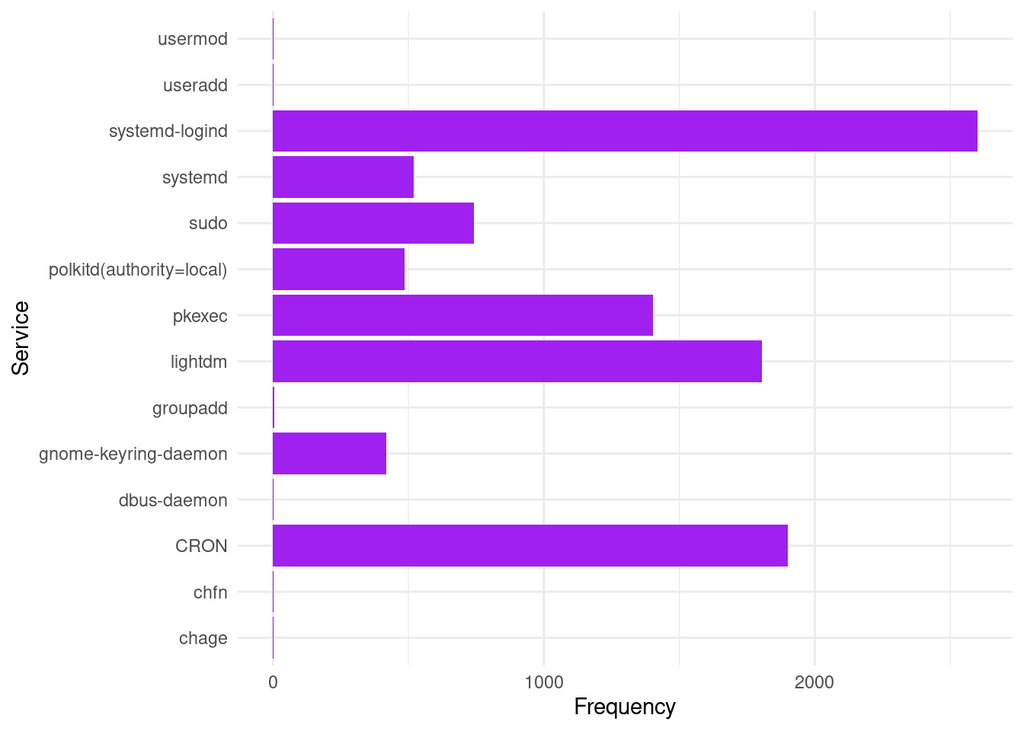

```r
  df_service_logs_frequency %>%
  ggplot() +
  geom_col(aes(Frequency, Service), fill = "PURPLE", width = 0.9)+
  theme_minimal()
```

### Respondendo a pergunta (Quantas e quais tentativas de autenticação falharam?)

9 tentativas de autenticação falharam. O dia e horário delas são distintos, o que indica que não há um padrão de tentativas maliciosas de login. As falhas foram resultado de ações não-intencionais de erro de senha do usuário.

```r
  msg_failure = "failed"
  df_failures <- df_logs %>% filter(str_detect(df_logs$Message,msg_failure))
```

```r
  df_failures %>%
  kbl() %>%
  kable_material()
```

| Timestamp | Service | Message | Day | Month | Year | Hour |
| --- | --- | --- | --- | --- | --- | --- |
| 2024-04-08 20:10:19 | sudo | pam_unix(sudo:auth): conversation failed | 8 | 4 | 2024 | 20 |
| 2024-04-10 16:11:10 | sudo | pam_unix(sudo:auth): conversation failed | 10 | 4 | 2024 | 16 |
| 2024-04-17 14:43:50 | sudo | pam_unix(sudo:auth): conversation failed | 17 | 4 | 2024 | 14 |
| 2024-04-27 14:29:40 | sudo | pam_unix(sudo:auth): conversation failed | 27 | 4 | 2024 | 14 |
| 2024-05-19 14:28:40 | sudo | pam_unix(sudo:auth): conversation failed | 19 | 5 | 2024 | 14 |
| 2024-05-21 14:19:56 | sudo | pam_unix(sudo:auth): conversation failed | 21 | 5 | 2024 | 14 |
| 2024-05-27 17:07:21 | sudo | pam_unix(sudo:auth): conversation failed | 27 | 5 | 2024 | 17 |
| 2024-05-29 15:41:24 | sudo | pam_unix(sudo:auth): conversation failed | 29 | 5 | 2024 | 15 |
| 2024-06-09 20:59:39 | sudo | pam_unix(sudo:auth): conversation failed | 9 | 6 | 2024 | 20 |

### Respondendo a pergunta (Quantas sessões de root são abertas em média por dia?)

A média de sessões abertas de root por dia no mês de abril foi de 18. Já no mês de maio foi de 21 e no mês de junho foi de 24. Tal fato indica que a quantidade de sessões de root abertas seguem um padrão homogêneo, provavelmente correspondente a um padrão de comportamento comum do usuário.

```r
    root_user = "root"
    root_session = "session opened"
    df_root <-
      df_logs %>%
      filter(str_detect(Message,root_user)) %>%
      filter(str_detect(Message,root_session)) %>%
      group_by(Month) %>%
      summarise(
        Frequency = n(),
        Avg_Root_Open_Sessions_Day = round((Frequency/unique(days_in_month(Month))),digits=0)
      )
```

```r
  df_root %>%
  kbl() %>%
  kable_styling(bootstrap_options = c("striped", "hover"))
```

| Month | Frequency | Avg_Root_Open_Sessions_Day |
| --- | --- | --- |
| 4 | 532 | 18 |
| 5 | 640 | 21 |
| 6 | 732 | 24 |

### Respondendo a pergunta (Quais são os horários de pico de tentativas de login?)

Os horários de pico de login no sistema são 14PM, 10AM, 19PM, 20PM e 5AM (Horário de 24 horas). Os eventos de login nesses horários contabilizam 55,6% do total de eventos.

```r
  df_login_time <-
    df_logs %>%
    filter(Service=="systemd-logind")
```

```r
  df_login_time_grouped <- df_login_time %>%
  group_by(Hour) %>%
   summarise(
     Login_Events = n(),
     Login_Events_Pct=round((n()/nrow(df_login_time))*100,digits=1)
    ) %>%
    arrange(desc(Login_Events))
```

```r
  df_login_time_grouped %>%
  kbl() %>%
  kable_minimal()
```

| Hour | Login_Events | Login_Events_Pct |
| --- | --- | --- |
| 14 | 452 | 17.4 |
| 10 | 294 | 11.3 |
| 19 | 289 | 11.1 |
| 20 | 218 | 8.4 |
| 5 | 192 | 7.4 |
| 9 | 154 | 5.9 |
| 18 | 147 | 5.7 |
| 17 | 142 | 5.5 |
| 11 | 135 | 5.2 |
| 13 | 104 | 4.0 |
| 16 | 96 | 3.7 |
| 21 | 88 | 3.4 |
| 7 | 75 | 2.9 |
| 15 | 58 | 2.2 |
| 12 | 49 | 1.9 |
| 6 | 47 | 1.8 |
| 22 | 45 | 1.7 |
| 8 | 14 | 0.5 |
| 1 | 2 | 0.1 |

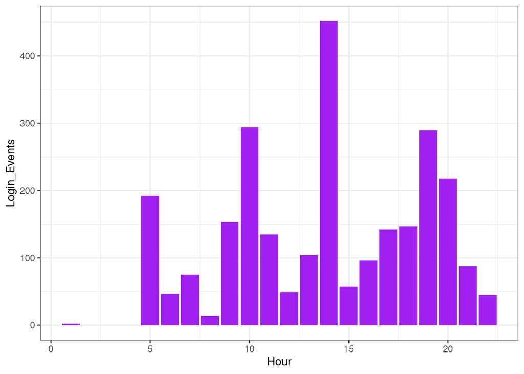

```r
  df_login_time_grouped %>%
  ggplot() +
  geom_col(aes(Hour, Login_Events), fill = "PURPLE", width = 0.9)+
  theme_bw()
```